# TItanic的生存数据集相关分析

## 1.数据清理

### 1.1部分数据值的说明

### 1.2对缺失值的处理

## 2.数据分析

### 2.1出发站对于生还率的影响

### 2.2船舱等级对于生还率的影响

### 2.3性别对于生还率的影响

### 2.4年龄对于生还率的影响

### 2.5家庭成员数量对于生还率的影响

### 2.6决策树算法对于各因素影响程度

## 3.结论及研究存在的相关限制

## 1.数据清理

```python
#导入相关库 以及数据
import pandas as pd
from pandas import Series, DataFrame
import numpy as np
import matplotlib.pyplot as plt
import seaborn as sns
titanic_df= pd.read_csv("titanic-data.csv")
titanic_df.head()
```

|  | PassengerId | Survived | Pclass | Name | Sex | Age | SibSp | Parch | Ticket | Fare | Cabin | Embarked |
| --- | --- | --- | --- | --- | --- | --- | --- | --- | --- | --- | --- | --- |
| 0 | 1 | 0 | 3 | Braund, Mr. Owen Harris | male | 22.0 | 1 | 0 | A/5 21171 | 7.2500 | NaN | S |
| 1 | 2 | 1 | 1 | Cumings, Mrs. John Bradley (Florence Briggs Th... | female | 38.0 | 1 | 0 | PC 17599 | 71.2833 | C85 | C |
| 2 | 3 | 1 | 3 | Heikkinen, Miss. Laina | female | 26.0 | 0 | 0 | STON/O2. 3101282 | 7.9250 | NaN | S |
| 3 | 4 | 1 | 1 | Futrelle, Mrs. Jacques Heath (Lily May Peel) | female | 35.0 | 1 | 0 | 113803 | 53.1000 | C123 | S |
| 4 | 5 | 0 | 3 | Allen, Mr. William Henry | male | 35.0 | 0 | 0 | 373450 | 8.0500 | NaN | S |

```python
#查看导入数据的基本信息
titanic_df.info()
```

```
<class 'pandas.core.frame.DataFrame'>
RangeIndex: 891 entries, 0 to 890
Data columns (total 12 columns):
PassengerId    891 non-null int64
Survived       891 non-null int64
Pclass         891 non-null int64
Name           891 non-null object
Sex            891 non-null object
Age            714 non-null float64
SibSp          891 non-null int64
Parch          891 non-null int64
Ticket         891 non-null object
Fare           891 non-null float64
Cabin          204 non-null object
Embarked       889 non-null object
dtypes: float64(2), int64(5), object(5)
memory usage: 83.6+ KB
```

```python
titanic_df_nomissing = titanic_df[~np.isnan(titanic_df.Age)] #去除Age的空缺值
titanic_df_nomissing.info()
```

```
<class 'pandas.core.frame.DataFrame'>
Int64Index: 714 entries, 0 to 890
Data columns (total 12 columns):
PassengerId    714 non-null int64
Survived       714 non-null int64
Pclass         714 non-null int64
Name           714 non-null object
Sex            714 non-null object
Age            714 non-null float64
SibSp          714 non-null int64
Parch          714 non-null int64
Ticket         714 non-null object
Fare           714 non-null float64
Cabin          185 non-null object
Embarked       712 non-null object
dtypes: float64(2), int64(5), object(5)
memory usage: 72.5+ KB
```

## 2.数据分析

### 2.1探究始发站与生还率的关系

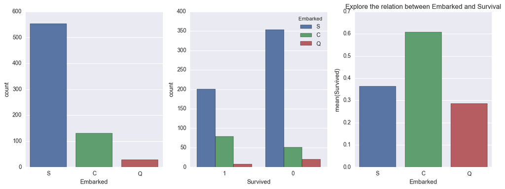

```python
%matplotlib inline
fig,(axis1,axis2,axis3) = plt.subplots(1,3,figsize=(15,5))
# 创建3个并列的空图像
sns.countplot(x='Embarked',data=titanic_df_nomissing, ax=axis1)
#创建第一个子图像，计算一下各个出发站的人数
sns.countplot(x='Survived', hue="Embarked", data=titanic_df_nomissing, order=[1,0], ax=axis2)
embark_perc = titanic_df_nomissing[["Embarked", "Survived"]].groupby(['Embarked'],as_index=False).mean()
sns.barplot(x='Embarked', y='Survived', data=embark_perc,order=['S','C','Q'],ax=axis3)
plt.title('Explore the relation between Embarked and Survival')
```

通过图形可以发现，从S站出发的人最多，C站次之，Q站最少，生还率最高的是从C站出发的人，生还率超过0.6，S站出发的人中有36%的人生还，生还率最低的是Q站出发的乘客，生还率只有0.28左右。可能原因是1.从C站出发的人中某一特定人群比例的生还率较高（妇女或儿童）2.从Q站出发的人数样本较少，有某几个船舱的人集中死亡导致整体的生还率不高。

### 2.2探究Pclass对于生还率的影响分析

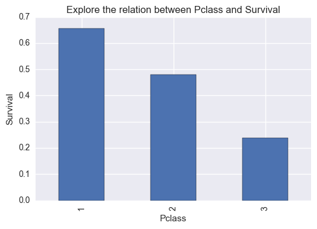

```python
group_by_pclass = titanic_df_nomissing.groupby('Pclass')['Survived'].mean()
group_by_pclass
group_by_pclass.plot(kind='bar') #绘制柱形图
plt.ylabel('Survival')
plt.xlabel('Pclass')
plt.title('Explore the relation between Pclass and Survival')
```

分析图像可以发现，根据图像可以发现1等舱的人生还率最高，达到0.65，二等舱的人次之，达到0.48左右，三等舱的人生还率最低，只有0.23左右。可能原因是1等舱位于Titanic号船体的上部，在下沉过程中有较长的逃生时间。

### 2.3探究年龄与生还几率的关系，因为人们会倾向于先救孩子，可能会使得儿童的生还率高于平均值。

[output not shown]

```
1    0.539823
0    0.460177
Name: Survived, dtype: float64
```

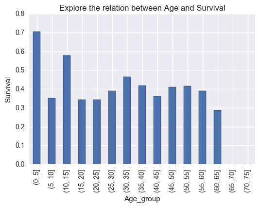

```python
titanic_df["Child"]= float('NaN') # create the column Child
titanic_df["Child"][titanic_df["Age"]<18]=1 #小于18岁的标记为孩子，大于18岁的标记为成人
titanic_df["Child"][titanic_df["Age"]>=18]=0
print(titanic_df["Survived"][titanic_df["Child"]==1].value_counts(normalize=True))

bins = np.arange(0,80,5)
titanic_df_nomissing['Age_group'] = pd.cut(titanic_df_nomissing['Age'], bins)
by_Age = titanic_df_nomissing.groupby('Age_group')['Survived'].mean()
by_Age.plot(kind = 'bar')
plt.ylabel('Survival')
plt.title('Explore the relation between Age and Survival')
```

从图中可以看到，0-5岁的孩子生还率最高，10-15岁的孩子生还率次之达到0.58，可以看出人们会优先抢救小孩子，5-10岁的孩子生还率较低，可能因为样本数量较少，导致了较大的误差，也可能是由于家庭成员的数量影响了其生还率。

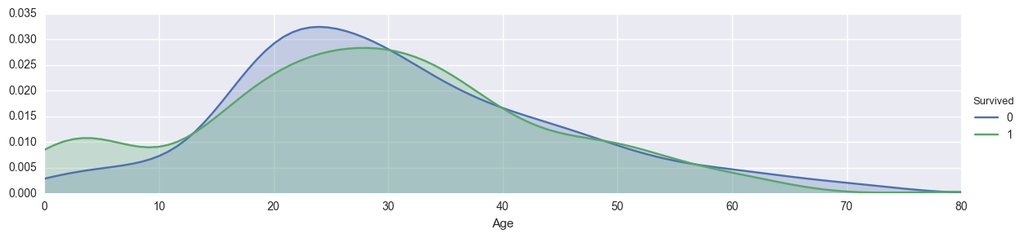

```python
facet = sns.FacetGrid(titanic_df_nomissing, hue="Survived",aspect=4)
facet.map(sns.kdeplot,'Age',shade= True) #Plot a basic univariate density 绘制概率密度函数
facet.set(xlim=(0, titanic_df_nomissing['Age'].max())) #设定坐标轴的范围
facet.add_legend()
```

### 2.4分析性别对生还率的影响

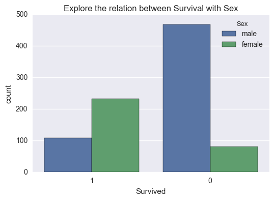

```python
sns.countplot(x='Survived', hue="Sex", data=titanic_df, order=[1,0])
plt.title('Explore the relation between Survival with Sex')
```

通过图像分析可以发现，女性的生还率明显高于男性。说明性别对于生还率有一定的影响。可能原因是在遇难时，女性被优先抢救。

### 2.5分析家庭成员的数量对生还率的影响，家庭成员数量较多的乘客会在遇难时互相帮助彼此，可能会有更大几率生还。

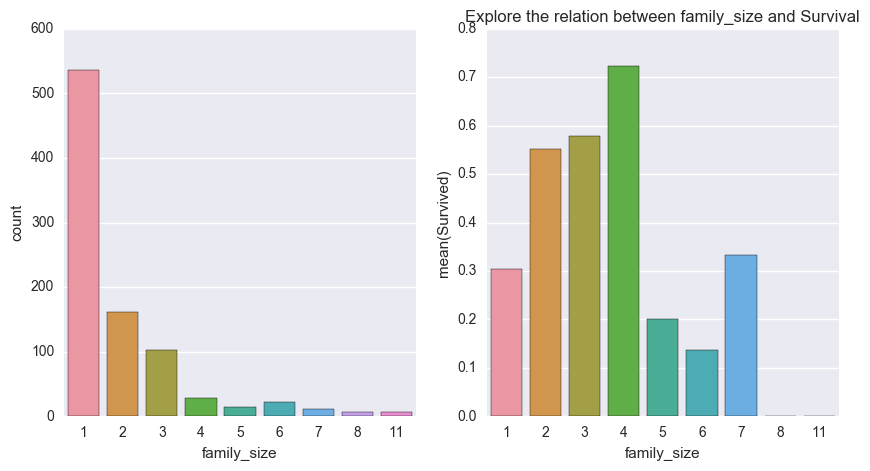

```python
titanic_df["family_size"] = titanic_df["SibSp"]+titanic_df["Parch"]+1
#创建新的数据列 家庭成员数量，利用已知的 SibSp变量和 Parch变量 得到 family_size变量
#绘制相关图形
fig, (axis1, axis2) = plt.subplots(1,2,sharex=True, figsize=(10,5))
sns.countplot(x='family_size',data=titanic_df,ax=axis1)
family_survival = titanic_df[["family_size","Survived"]].groupby(['family_size'],as_index = False).mean()
#分组计算各个family_size的生还率
sns.barplot(x="family_size", y="Survived",data=family_survival,ax=axis2)
plt.title('Explore the relation between family_size and Survival')
```

通过绘图可以发现family_size为2-4时有较大的生还几率，而family_size过大可能会对生还率产生副作用。

### 2.6利用Decision tree算法计算各个因素对生还率的影响程度

```python
from sklearn import tree
titanic_df_nomissing["Sex"][titanic_df_nomissing["Sex"] =="male"] =0
titanic_df_nomissing["Sex"][titanic_df_nomissing["Sex"] =="female"] =1


target =titanic_df_nomissing["Survived"].values
features_one = titanic_df_nomissing[["Pclass","Age","Sex","Parch"]].values

my_tree = tree.DecisionTreeClassifier()
my_tree = my_tree.fit(features_one,target)
print(my_tree.feature_importances_)
```

```
[ 0.1798137   0.37137389  0.37957065  0.06924176]
```

[output not shown]

分析结果显示， 船舱等级，年龄，性别，父母/孩子数量对于生还率的影响分别占 0.18,0.37,0.38,0.07的比例

## 结论及分析的限制

分析存在的限制：由于生还率与很多其它因素有关，例如救生船的数量，船舱的位置，个人的求生技巧，而以上几个方面的数据该数据集都没有提供，所以会对分析结果的准确性产生一定的影响。

### 参考文件的列表：

kaggle网站 kaggle网站 "A journey through Titanic"分析实例  
Datacamp网站kaggle入门教程 pyplot文档 seaborn文档